# LSOCV-v4-reviewer-comments-28-07-26

## model= ridge filter= 0.05 outcome= lbo clin feat= none

|  | Accuracy | Sensitivity | Specificity | AUC |
| --- | --- | --- | --- | --- |
| metric.mean.df | 0.68 | 0.656 | 0.698 | 0.763 |
| metric.quantiles | (0.68-0.68) | (0.656-0.656) | (0.698-0.698) | (0.763-0.763) |

|  | NPO-reference | Live_birth-reference |
| --- | --- | --- |
| NPO-prediction | 30 | 11 |
| Live_birth-prediction | 13 | 21 |

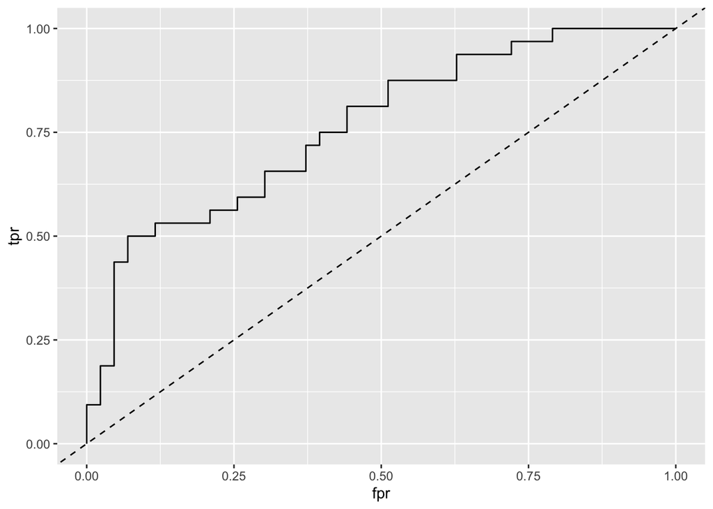

## model= ridge filter= 0.05 outcome= lbo clin feat= age

|  | Accuracy | Sensitivity | Specificity | AUC |
| --- | --- | --- | --- | --- |
| metric.mean.df | 0.667 | 0.656 | 0.674 | 0.762 |
| metric.quantiles | (0.667-0.667) | (0.656-0.656) | (0.674-0.674) | (0.762-0.762) |

|  | NPO-reference | Live_birth-reference |
| --- | --- | --- |
| NPO-prediction | 29 | 11 |
| Live_birth-prediction | 14 | 21 |

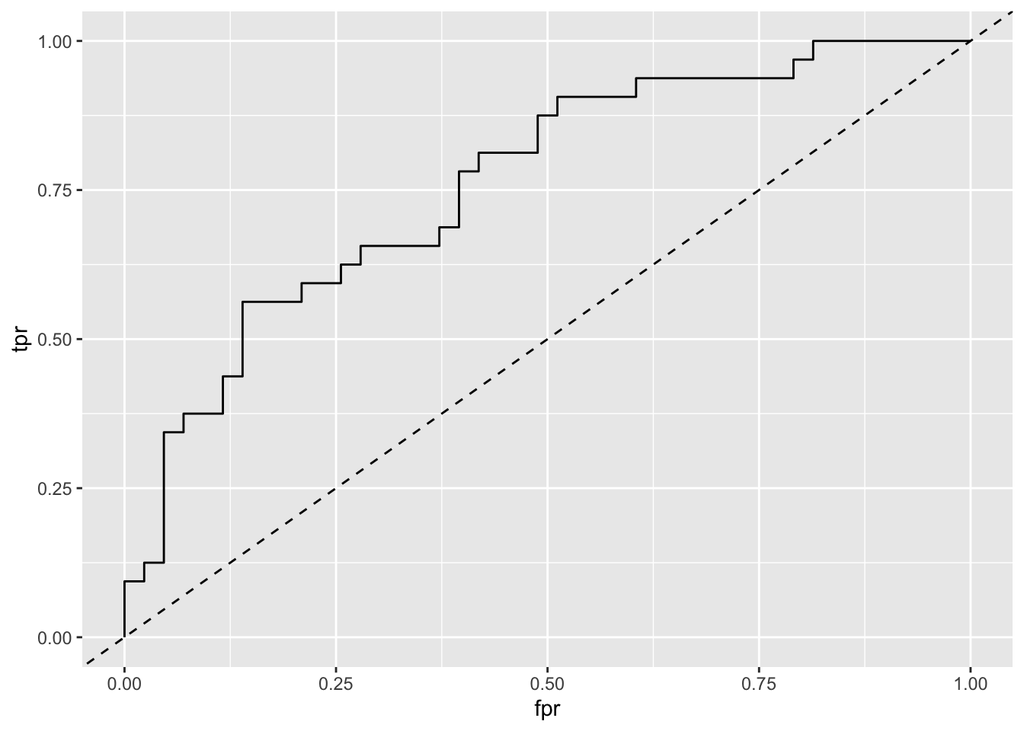

## model= ridge filter= 0.05 outcome= lbo clin feat= g1+g2+g3

|  | Accuracy | Sensitivity | Specificity | AUC |
| --- | --- | --- | --- | --- |
| metric.mean.df | 0.667 | 0.719 | 0.628 | 0.752 |
| metric.quantiles | (0.667-0.667) | (0.719-0.719) | (0.628-0.628) | (0.752-0.752) |

|  | NPO-reference | Live_birth-reference |
| --- | --- | --- |
| NPO-prediction | 27 | 9 |
| Live_birth-prediction | 16 | 23 |

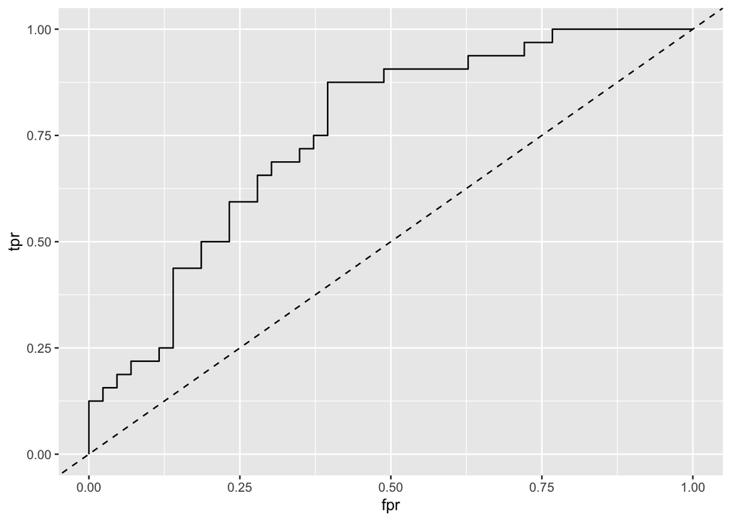

## model= ridge filter= 0.05 outcome= lbo clin feat= g1+g2+g3+age

|  | Accuracy | Sensitivity | Specificity | AUC |
| --- | --- | --- | --- | --- |
| metric.mean.df | 0.693 | 0.719 | 0.674 | 0.764 |
| metric.quantiles | (0.693-0.693) | (0.719-0.719) | (0.674-0.674) | (0.764-0.764) |

|  | NPO-reference | Live_birth-reference |
| --- | --- | --- |
| NPO-prediction | 29 | 9 |
| Live_birth-prediction | 14 | 23 |

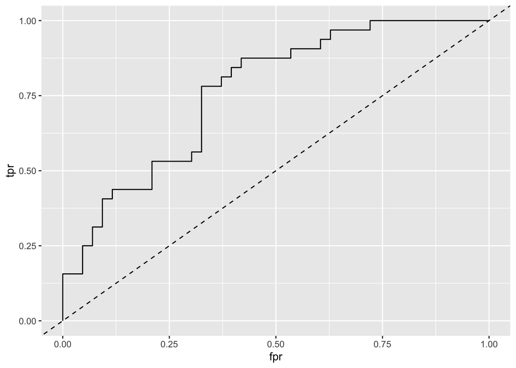

## model= ridge filter= 0.05 outcome= lbo clin feat= g3

|  | Accuracy | Sensitivity | Specificity | AUC |
| --- | --- | --- | --- | --- |
| metric.mean.df | 0.733 | 0.781 | 0.698 | 0.789 |
| metric.quantiles | (0.733-0.733) | (0.781-0.781) | (0.698-0.698) | (0.789-0.789) |

|  | NPO-reference | Live_birth-reference |
| --- | --- | --- |
| NPO-prediction | 30 | 7 |
| Live_birth-prediction | 13 | 25 |

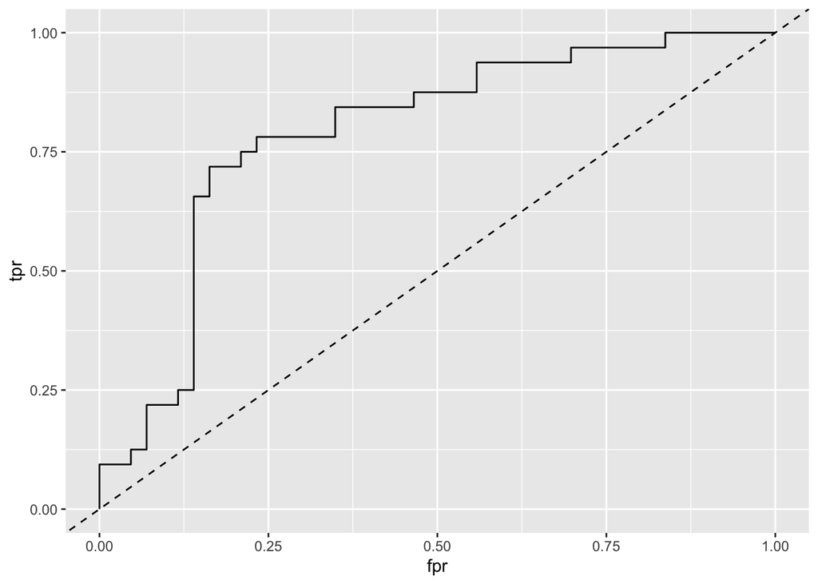

## model= ridge filter= 0.05 outcome= lbo clin feat= g3+age

|  | Accuracy | Sensitivity | Specificity | AUC |
| --- | --- | --- | --- | --- |
| metric.mean.df | 0.76 | 0.781 | 0.744 | 0.782 |
| metric.quantiles | (0.76-0.76) | (0.781-0.781) | (0.744-0.744) | (0.782-0.782) |

|  | NPO-reference | Live_birth-reference |
| --- | --- | --- |
| NPO-prediction | 32 | 7 |
| Live_birth-prediction | 11 | 25 |

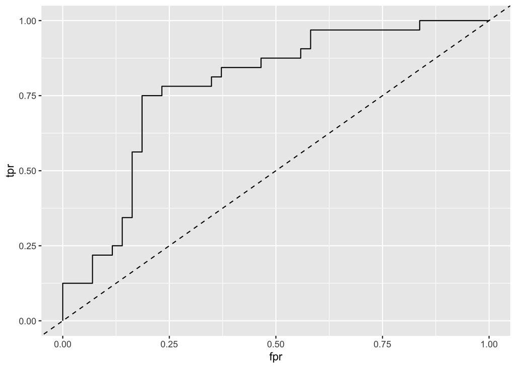

## model= ridge filter= 0.1 outcome= lbo clin feat= none

|  | Accuracy | Sensitivity | Specificity | AUC |
| --- | --- | --- | --- | --- |
| metric.mean.df | 0.76 | 0.719 | 0.791 | 0.778 |
| metric.quantiles | (0.76-0.76) | (0.719-0.719) | (0.791-0.791) | (0.778-0.778) |

|  | NPO-reference | Live_birth-reference |
| --- | --- | --- |
| NPO-prediction | 34 | 9 |
| Live_birth-prediction | 9 | 23 |

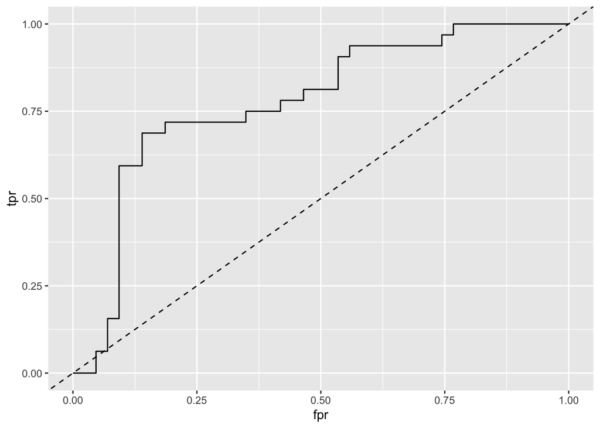

## model= ridge filter= 0.1 outcome= lbo clin feat= age

|  | Accuracy | Sensitivity | Specificity | AUC |
| --- | --- | --- | --- | --- |
| metric.mean.df | 0.733 | 0.688 | 0.767 | 0.768 |
| metric.quantiles | (0.733-0.733) | (0.688-0.688) | (0.767-0.767) | (0.768-0.768) |

|  | NPO-reference | Live_birth-reference |
| --- | --- | --- |
| NPO-prediction | 33 | 10 |
| Live_birth-prediction | 10 | 22 |

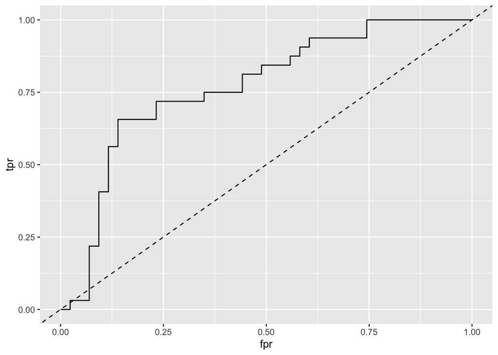

## model= ridge filter= 0.1 outcome= lbo clin feat= g1+g2+g3

|  | Accuracy | Sensitivity | Specificity | AUC |
| --- | --- | --- | --- | --- |
| metric.mean.df | 0.693 | 0.625 | 0.744 | 0.762 |
| metric.quantiles | (0.693-0.693) | (0.625-0.625) | (0.744-0.744) | (0.762-0.762) |

|  | NPO-reference | Live_birth-reference |
| --- | --- | --- |
| NPO-prediction | 32 | 12 |
| Live_birth-prediction | 11 | 20 |

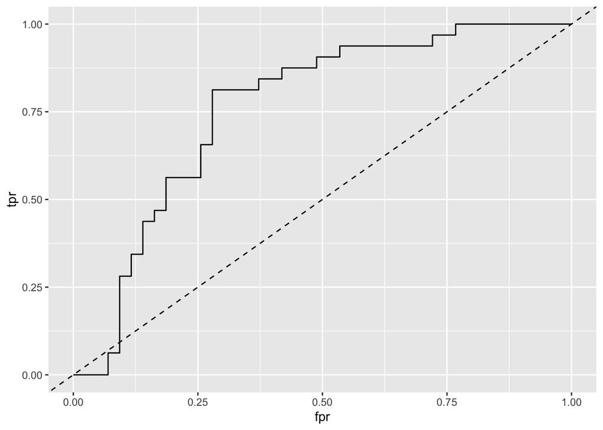

## model= ridge filter= 0.1 outcome= lbo clin feat= g1+g2+g3+age

|  | Accuracy | Sensitivity | Specificity | AUC |
| --- | --- | --- | --- | --- |
| metric.mean.df | 0.693 | 0.656 | 0.721 | 0.785 |
| metric.quantiles | (0.693-0.693) | (0.656-0.656) | (0.721-0.721) | (0.785-0.785) |

|  | NPO-reference | Live_birth-reference |
| --- | --- | --- |
| NPO-prediction | 31 | 11 |
| Live_birth-prediction | 12 | 21 |

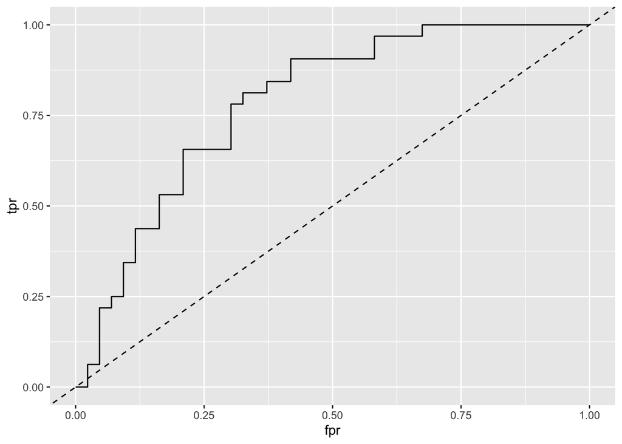

## model= ridge filter= 0.1 outcome= lbo clin feat= g3

|  | Accuracy | Sensitivity | Specificity | AUC |
| --- | --- | --- | --- | --- |
| metric.mean.df | 0.787 | 0.75 | 0.814 | 0.782 |
| metric.quantiles | (0.787-0.787) | (0.75-0.75) | (0.814-0.814) | (0.782-0.782) |

|  | NPO-reference | Live_birth-reference |
| --- | --- | --- |
| NPO-prediction | 35 | 8 |
| Live_birth-prediction | 8 | 24 |

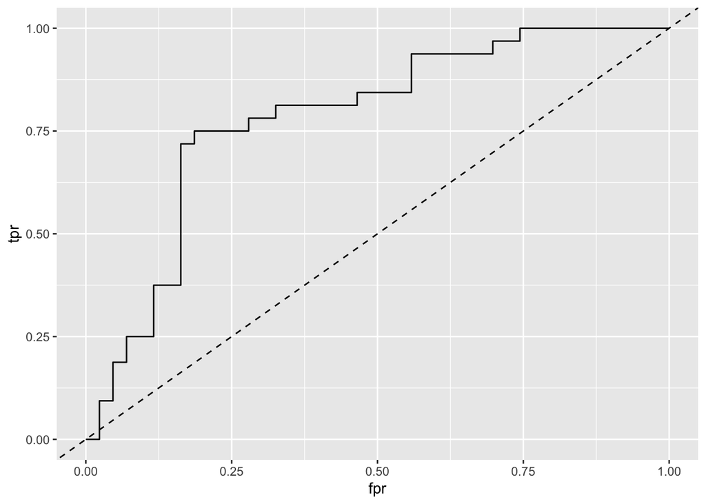

## model= ridge filter= 0.1 outcome= lbo clin feat= g3+age

|  | Accuracy | Sensitivity | Specificity | AUC |
| --- | --- | --- | --- | --- |
| metric.mean.df | 0.773 | 0.75 | 0.791 | 0.79 |
| metric.quantiles | (0.773-0.773) | (0.75-0.75) | (0.791-0.791) | (0.79-0.79) |

|  | NPO-reference | Live_birth-reference |
| --- | --- | --- |
| NPO-prediction | 34 | 8 |
| Live_birth-prediction | 9 | 24 |

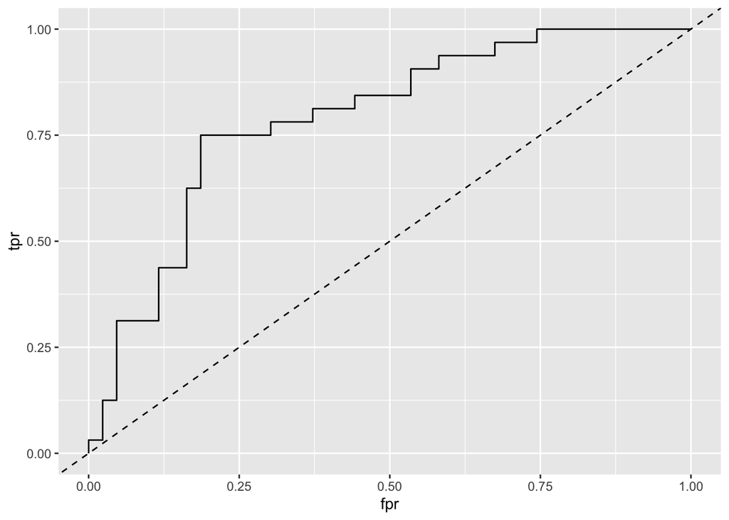

## model= rf filter= 0.05 outcome= hCG clin feat= none

|  | Accuracy | Sensitivity | Specificity | AUC |
| --- | --- | --- | --- | --- |
| metric.mean.df | 0.667 | 0.737 | 0.595 | 0.707 |
| metric.quantiles | (0.667-0.667) | (0.737-0.737) | (0.595-0.595) | (0.707-0.707) |

|  | Negative-reference | Positive-reference |
| --- | --- | --- |
| Negative-prediction | 22 | 10 |
| Positive-prediction | 15 | 28 |

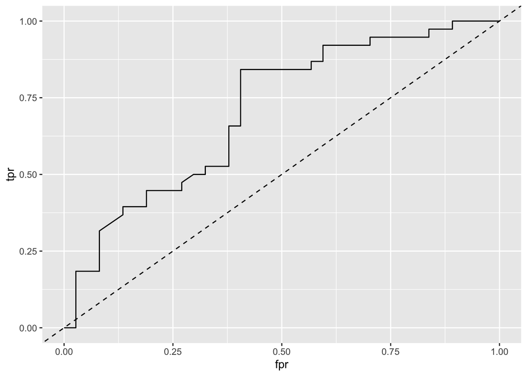

## model= rf filter= 0.05 outcome= hCG clin feat= age

|  | Accuracy | Sensitivity | Specificity | AUC |
| --- | --- | --- | --- | --- |
| metric.mean.df | 0.653 | 0.684 | 0.622 | 0.703 |
| metric.quantiles | (0.653-0.653) | (0.684-0.684) | (0.622-0.622) | (0.703-0.703) |

|  | Negative-reference | Positive-reference |
| --- | --- | --- |
| Negative-prediction | 23 | 12 |
| Positive-prediction | 14 | 26 |

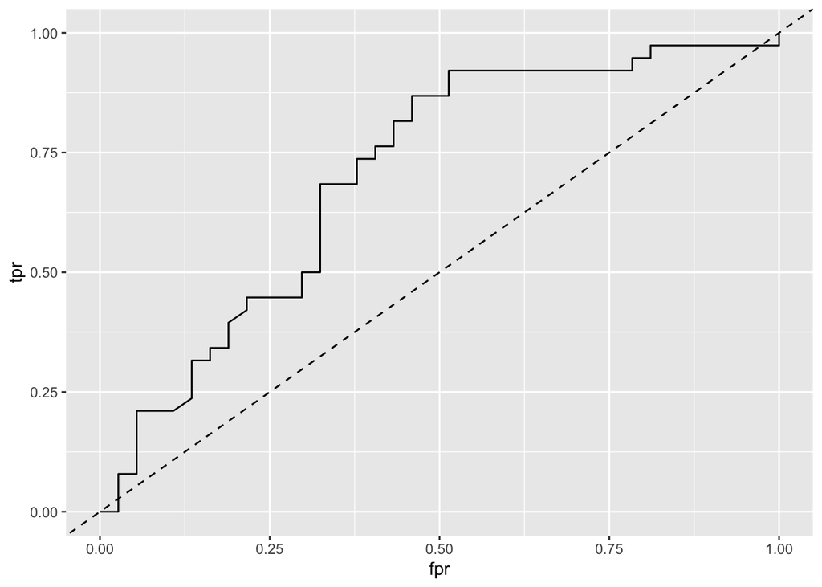

## model= rf filter= 0.05 outcome= hCG clin feat= g1+g2+g3

|  | Accuracy | Sensitivity | Specificity | AUC |
| --- | --- | --- | --- | --- |
| metric.mean.df | 0.693 | 0.763 | 0.622 | 0.733 |
| metric.quantiles | (0.693-0.693) | (0.763-0.763) | (0.622-0.622) | (0.733-0.733) |

|  | Negative-reference | Positive-reference |
| --- | --- | --- |
| Negative-prediction | 23 | 9 |
| Positive-prediction | 14 | 29 |

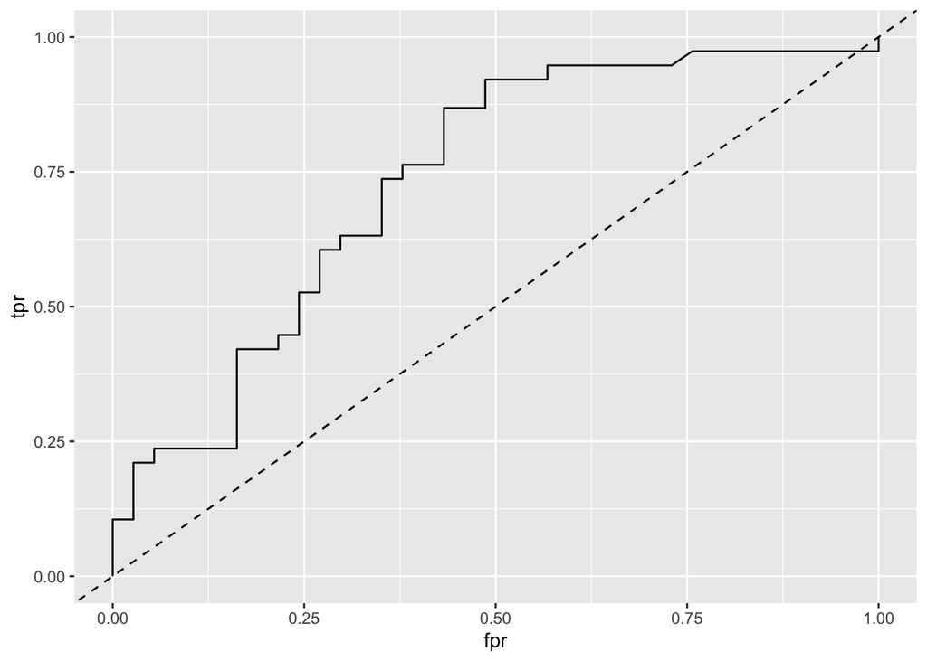

## model= rf filter= 0.05 outcome= hCG clin feat= g1+g2+g3+age

|  | Accuracy | Sensitivity | Specificity | AUC |
| --- | --- | --- | --- | --- |
| metric.mean.df | 0.68 | 0.763 | 0.595 | 0.712 |
| metric.quantiles | (0.68-0.68) | (0.763-0.763) | (0.595-0.595) | (0.712-0.712) |

|  | Negative-reference | Positive-reference |
| --- | --- | --- |
| Negative-prediction | 22 | 9 |
| Positive-prediction | 15 | 29 |

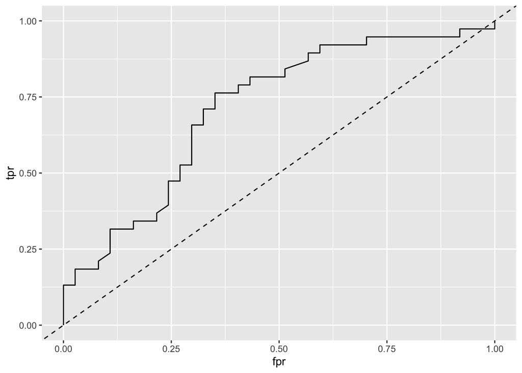

## model= rf filter= 0.05 outcome= hCG clin feat= g3

|  | Accuracy | Sensitivity | Specificity | AUC |
| --- | --- | --- | --- | --- |
| metric.mean.df | 0.653 | 0.711 | 0.595 | 0.716 |
| metric.quantiles | (0.653-0.653) | (0.711-0.711) | (0.595-0.595) | (0.716-0.716) |

|  | Negative-reference | Positive-reference |
| --- | --- | --- |
| Negative-prediction | 22 | 11 |
| Positive-prediction | 15 | 27 |

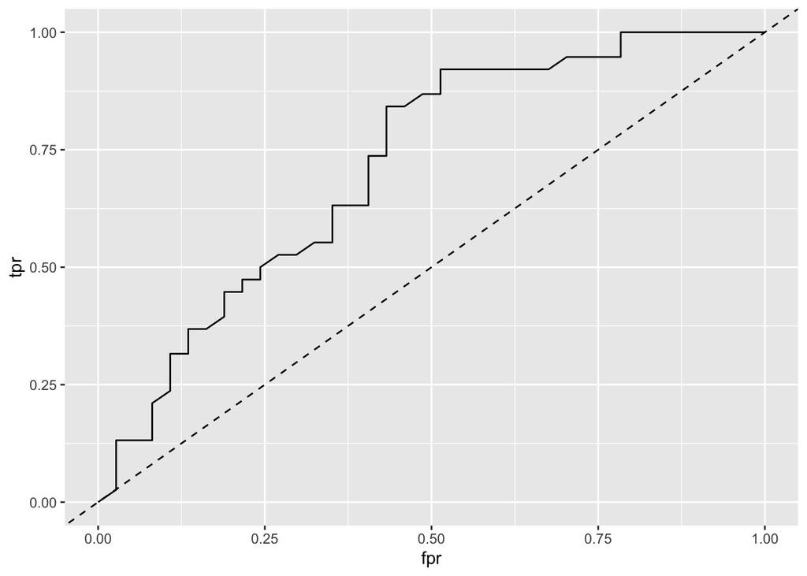

## model= rf filter= 0.05 outcome= hCG clin feat= g3+age

|  | Accuracy | Sensitivity | Specificity | AUC |
| --- | --- | --- | --- | --- |
| metric.mean.df | 0.68 | 0.763 | 0.595 | 0.693 |
| metric.quantiles | (0.68-0.68) | (0.763-0.763) | (0.595-0.595) | (0.693-0.693) |

|  | Negative-reference | Positive-reference |
| --- | --- | --- |
| Negative-prediction | 22 | 9 |
| Positive-prediction | 15 | 29 |

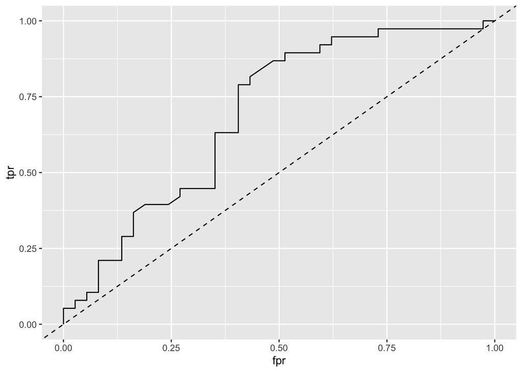

## model= rf filter= 0.1 outcome= hCG clin feat= none

|  | Accuracy | Sensitivity | Specificity | AUC |
| --- | --- | --- | --- | --- |
| metric.mean.df | 0.72 | 0.763 | 0.676 | 0.778 |
| metric.quantiles | (0.72-0.72) | (0.763-0.763) | (0.676-0.676) | (0.778-0.778) |

|  | Negative-reference | Positive-reference |
| --- | --- | --- |
| Negative-prediction | 25 | 9 |
| Positive-prediction | 12 | 29 |

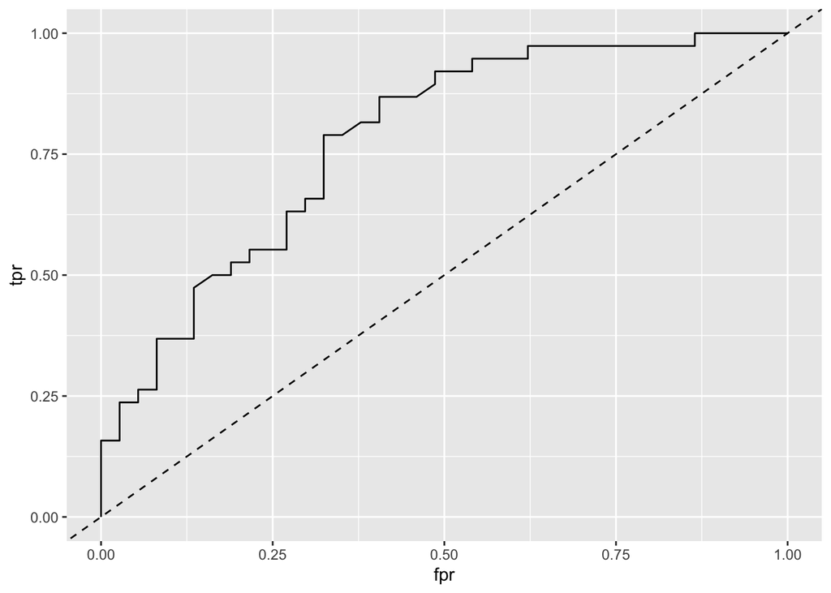

## model= rf filter= 0.1 outcome= hCG clin feat= age

|  | Accuracy | Sensitivity | Specificity | AUC |
| --- | --- | --- | --- | --- |
| metric.mean.df | 0.653 | 0.711 | 0.595 | 0.754 |
| metric.quantiles | (0.653-0.653) | (0.711-0.711) | (0.595-0.595) | (0.754-0.754) |

|  | Negative-reference | Positive-reference |
| --- | --- | --- |
| Negative-prediction | 22 | 11 |
| Positive-prediction | 15 | 27 |

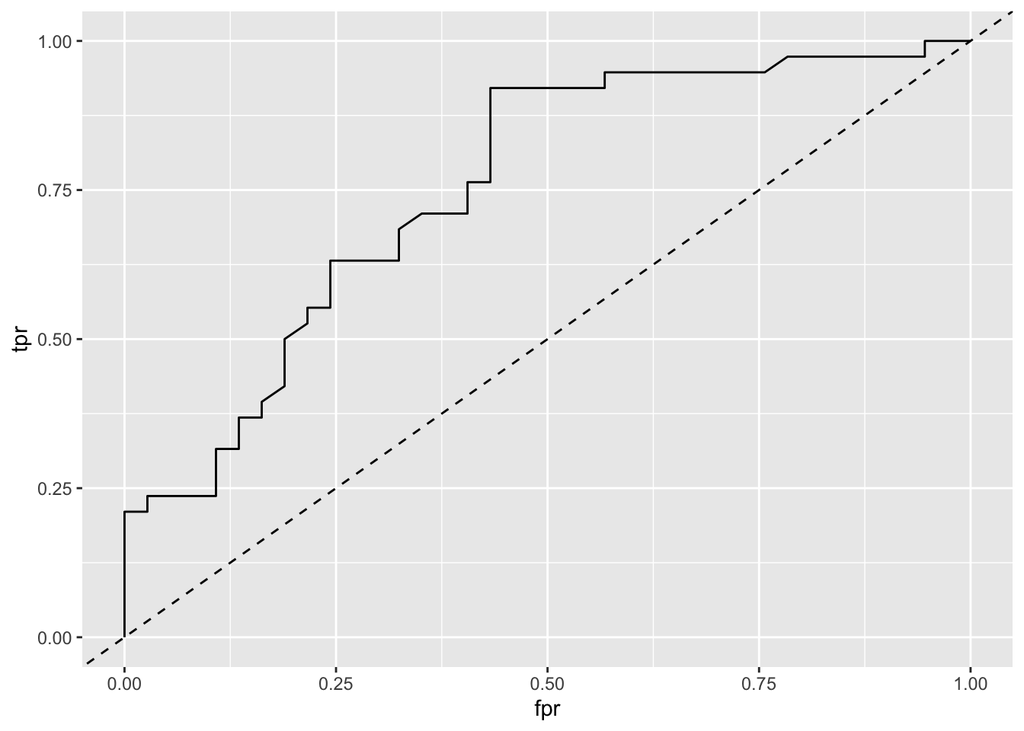

## model= rf filter= 0.1 outcome= hCG clin feat= g1+g2+g3

|  | Accuracy | Sensitivity | Specificity | AUC |
| --- | --- | --- | --- | --- |
| metric.mean.df | 0.693 | 0.763 | 0.622 | 0.777 |
| metric.quantiles | (0.693-0.693) | (0.763-0.763) | (0.622-0.622) | (0.777-0.777) |

|  | Negative-reference | Positive-reference |
| --- | --- | --- |
| Negative-prediction | 23 | 9 |
| Positive-prediction | 14 | 29 |

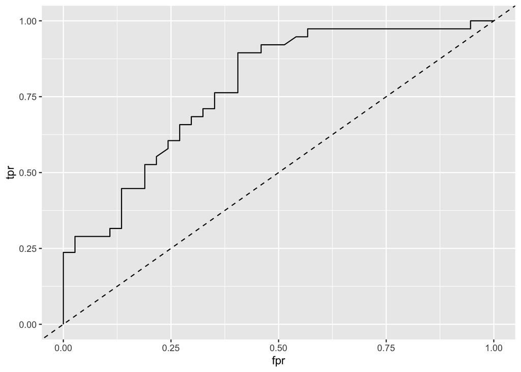

## model= rf filter= 0.1 outcome= hCG clin feat= g1+g2+g3+age

|  | Accuracy | Sensitivity | Specificity | AUC |
| --- | --- | --- | --- | --- |
| metric.mean.df | 0.733 | 0.789 | 0.676 | 0.78 |
| metric.quantiles | (0.733-0.733) | (0.789-0.789) | (0.676-0.676) | (0.78-0.78) |

|  | Negative-reference | Positive-reference |
| --- | --- | --- |
| Negative-prediction | 25 | 8 |
| Positive-prediction | 12 | 30 |

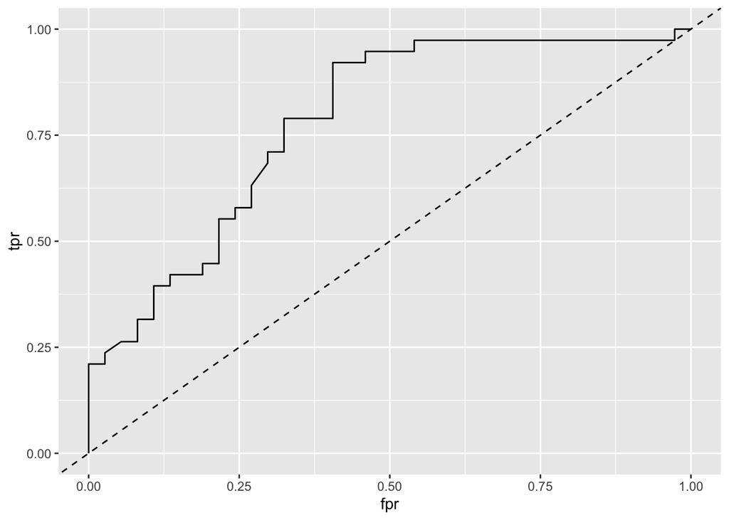

## model= rf filter= 0.1 outcome= hCG clin feat= g3

|  | Accuracy | Sensitivity | Specificity | AUC |
| --- | --- | --- | --- | --- |
| metric.mean.df | 0.667 | 0.737 | 0.595 | 0.766 |
| metric.quantiles | (0.667-0.667) | (0.737-0.737) | (0.595-0.595) | (0.766-0.766) |

|  | Negative-reference | Positive-reference |
| --- | --- | --- |
| Negative-prediction | 22 | 10 |
| Positive-prediction | 15 | 28 |

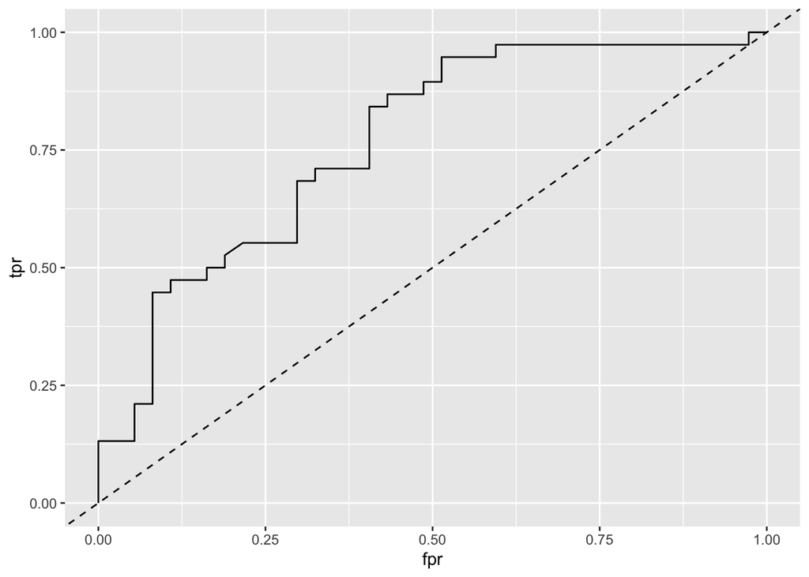

## model= rf filter= 0.1 outcome= hCG clin feat= g3+age

|  | Accuracy | Sensitivity | Specificity | AUC |
| --- | --- | --- | --- | --- |
| metric.mean.df | 0.707 | 0.763 | 0.649 | 0.774 |
| metric.quantiles | (0.707-0.707) | (0.763-0.763) | (0.649-0.649) | (0.774-0.774) |

|  | Negative-reference | Positive-reference |
| --- | --- | --- |
| Negative-prediction | 24 | 9 |
| Positive-prediction | 13 | 29 |

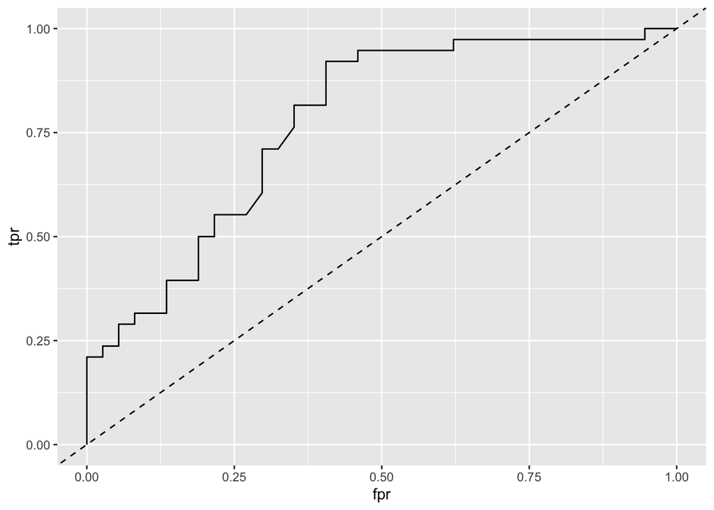

## model= rf filter= 0.05 outcome= lbo clin feat= none

|  | Accuracy | Sensitivity | Specificity | AUC |
| --- | --- | --- | --- | --- |
| metric.mean.df | 0.627 | 0.531 | 0.698 | 0.689 |
| metric.quantiles | (0.627-0.627) | (0.531-0.531) | (0.698-0.698) | (0.689-0.689) |

|  | NPO-reference | Live_birth-reference |
| --- | --- | --- |
| NPO-prediction | 30 | 15 |
| Live_birth-prediction | 13 | 17 |

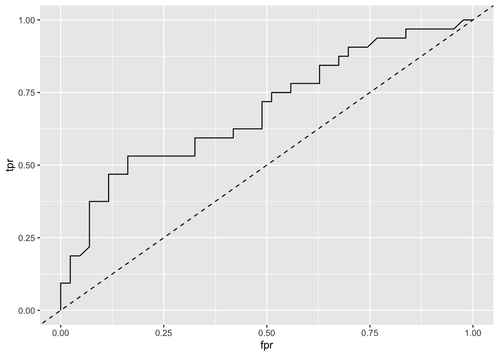

## model= rf filter= 0.05 outcome= lbo clin feat= age

|  | Accuracy | Sensitivity | Specificity | AUC |
| --- | --- | --- | --- | --- |
| metric.mean.df | 0.6 | 0.5 | 0.674 | 0.698 |
| metric.quantiles | (0.6-0.6) | (0.5-0.5) | (0.674-0.674) | (0.698-0.698) |

|  | NPO-reference | Live_birth-reference |
| --- | --- | --- |
| NPO-prediction | 29 | 16 |
| Live_birth-prediction | 14 | 16 |

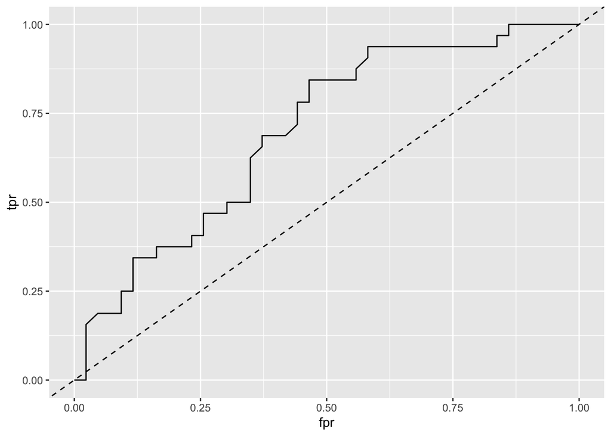

## model= rf filter= 0.05 outcome= lbo clin feat= g1+g2+g3

|  | Accuracy | Sensitivity | Specificity | AUC |
| --- | --- | --- | --- | --- |
| metric.mean.df | 0.64 | 0.594 | 0.674 | 0.737 |
| metric.quantiles | (0.64-0.64) | (0.594-0.594) | (0.674-0.674) | (0.737-0.737) |

|  | NPO-reference | Live_birth-reference |
| --- | --- | --- |
| NPO-prediction | 29 | 13 |
| Live_birth-prediction | 14 | 19 |

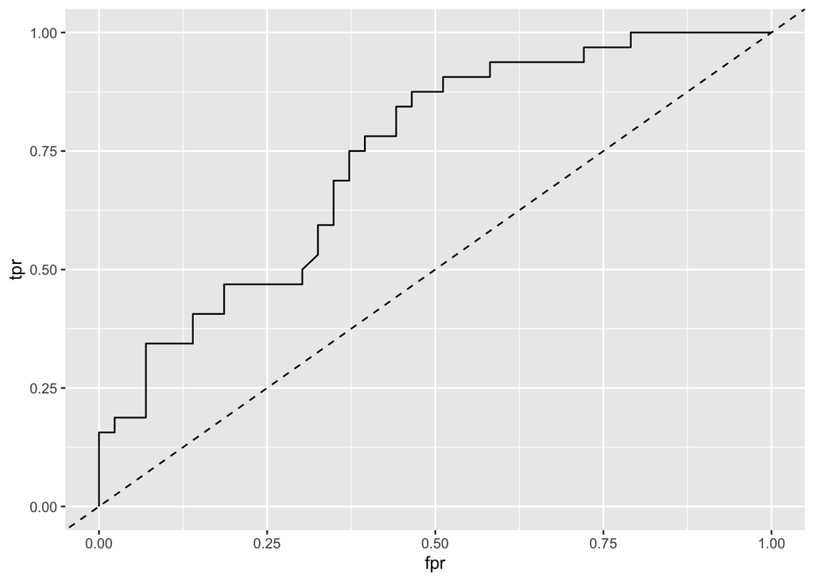

## model= rf filter= 0.05 outcome= lbo clin feat= g1+g2+g3+age

|  | Accuracy | Sensitivity | Specificity | AUC |
| --- | --- | --- | --- | --- |
| metric.mean.df | 0.613 | 0.594 | 0.628 | 0.733 |
| metric.quantiles | (0.613-0.613) | (0.594-0.594) | (0.628-0.628) | (0.733-0.733) |

|  | NPO-reference | Live_birth-reference |
| --- | --- | --- |
| NPO-prediction | 27 | 13 |
| Live_birth-prediction | 16 | 19 |

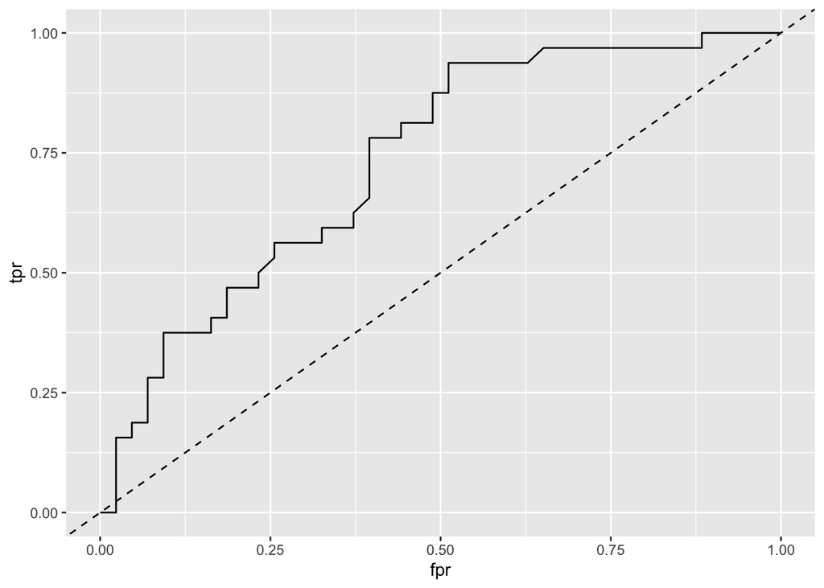

## model= rf filter= 0.05 outcome= lbo clin feat= g3

|  | Accuracy | Sensitivity | Specificity | AUC |
| --- | --- | --- | --- | --- |
| metric.mean.df | 0.627 | 0.562 | 0.674 | 0.681 |
| metric.quantiles | (0.627-0.627) | (0.562-0.562) | (0.674-0.674) | (0.681-0.681) |

|  | NPO-reference | Live_birth-reference |
| --- | --- | --- |
| NPO-prediction | 29 | 14 |
| Live_birth-prediction | 14 | 18 |

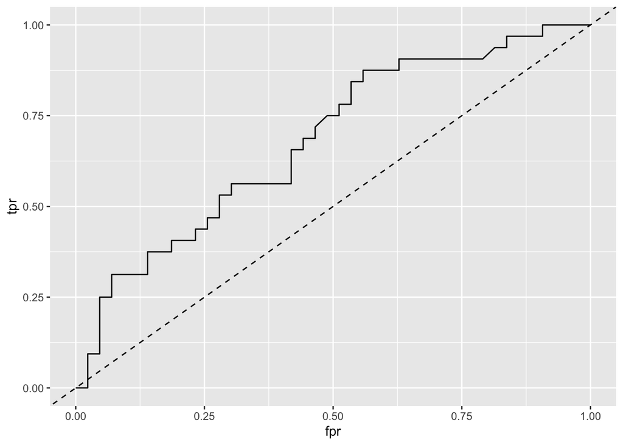

## model= rf filter= 0.05 outcome= lbo clin feat= g3+age

|  | Accuracy | Sensitivity | Specificity | AUC |
| --- | --- | --- | --- | --- |
| metric.mean.df | 0.627 | 0.594 | 0.651 | 0.706 |
| metric.quantiles | (0.627-0.627) | (0.594-0.594) | (0.651-0.651) | (0.706-0.706) |

|  | NPO-reference | Live_birth-reference |
| --- | --- | --- |
| NPO-prediction | 28 | 13 |
| Live_birth-prediction | 15 | 19 |

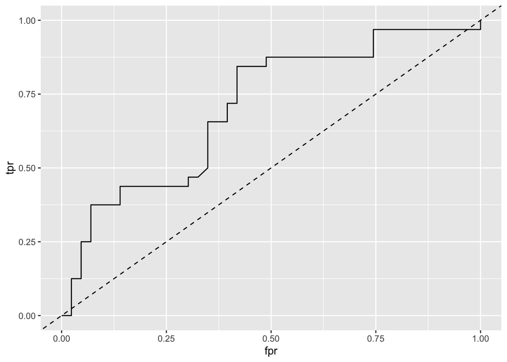

## model= rf filter= 0.1 outcome= lbo clin feat= none

|  | Accuracy | Sensitivity | Specificity | AUC |
| --- | --- | --- | --- | --- |
| metric.mean.df | 0.653 | 0.531 | 0.744 | 0.741 |
| metric.quantiles | (0.653-0.653) | (0.531-0.531) | (0.744-0.744) | (0.741-0.741) |

|  | NPO-reference | Live_birth-reference |
| --- | --- | --- |
| NPO-prediction | 32 | 15 |
| Live_birth-prediction | 11 | 17 |

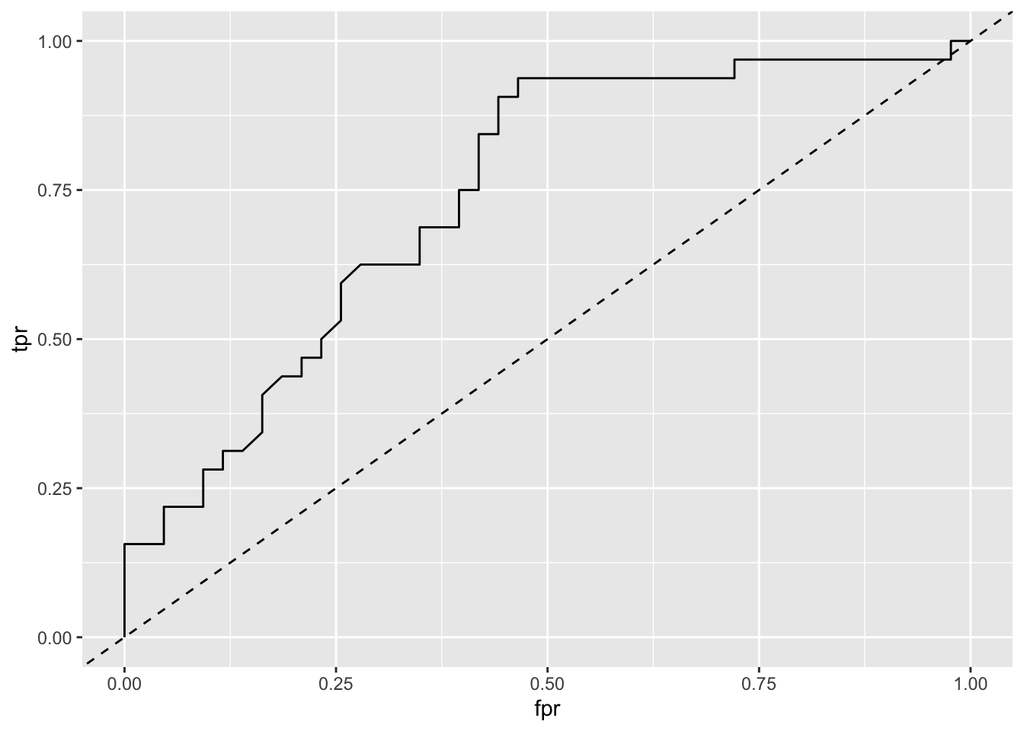

## model= rf filter= 0.1 outcome= lbo clin feat= age

|  | Accuracy | Sensitivity | Specificity | AUC |
| --- | --- | --- | --- | --- |
| metric.mean.df | 0.653 | 0.594 | 0.698 | 0.703 |
| metric.quantiles | (0.653-0.653) | (0.594-0.594) | (0.698-0.698) | (0.703-0.703) |

|  | NPO-reference | Live_birth-reference |
| --- | --- | --- |
| NPO-prediction | 30 | 13 |
| Live_birth-prediction | 13 | 19 |

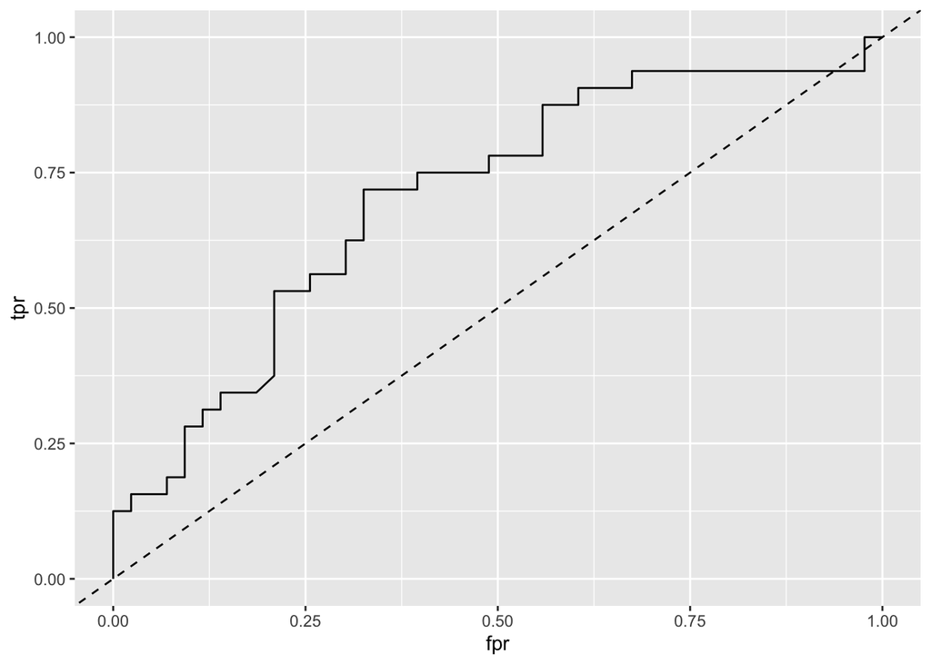

## model= rf filter= 0.1 outcome= lbo clin feat= g1+g2+g3

|  | Accuracy | Sensitivity | Specificity | AUC |
| --- | --- | --- | --- | --- |
| metric.mean.df | 0.707 | 0.656 | 0.744 | 0.762 |
| metric.quantiles | (0.707-0.707) | (0.656-0.656) | (0.744-0.744) | (0.762-0.762) |

|  | NPO-reference | Live_birth-reference |
| --- | --- | --- |
| NPO-prediction | 32 | 11 |
| Live_birth-prediction | 11 | 21 |

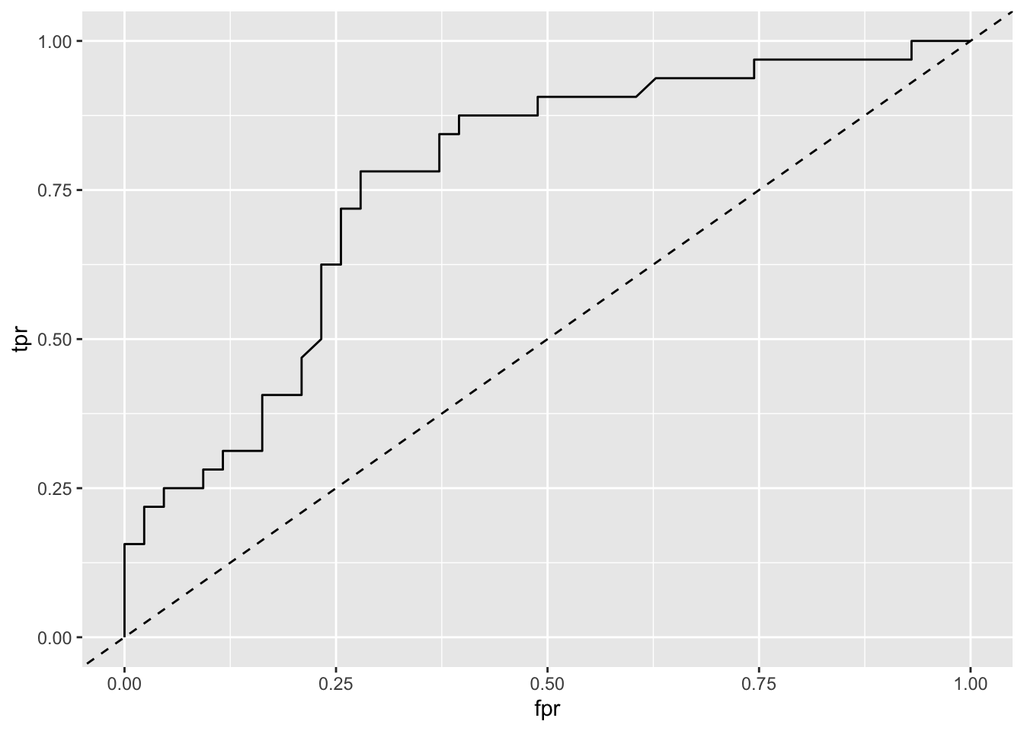

## model= rf filter= 0.1 outcome= lbo clin feat= g1+g2+g3+age

|  | Accuracy | Sensitivity | Specificity | AUC |
| --- | --- | --- | --- | --- |
| metric.mean.df | 0.68 | 0.625 | 0.721 | 0.721 |
| metric.quantiles | (0.68-0.68) | (0.625-0.625) | (0.721-0.721) | (0.721-0.721) |

|  | NPO-reference | Live_birth-reference |
| --- | --- | --- |
| NPO-prediction | 31 | 12 |
| Live_birth-prediction | 12 | 20 |

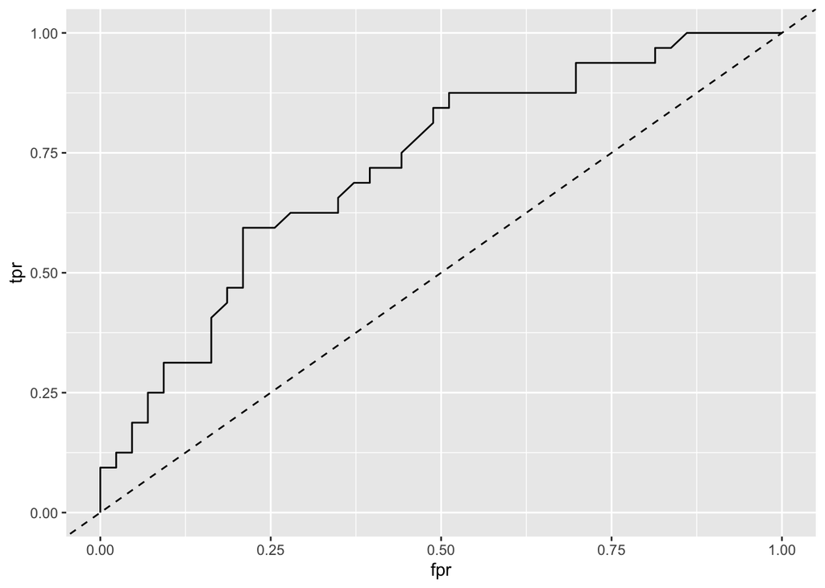

## model= rf filter= 0.1 outcome= lbo clin feat= g3

|  | Accuracy | Sensitivity | Specificity | AUC |
| --- | --- | --- | --- | --- |
| metric.mean.df | 0.707 | 0.688 | 0.721 | 0.747 |
| metric.quantiles | (0.707-0.707) | (0.688-0.688) | (0.721-0.721) | (0.747-0.747) |

|  | NPO-reference | Live_birth-reference |
| --- | --- | --- |
| NPO-prediction | 31 | 10 |
| Live_birth-prediction | 12 | 22 |

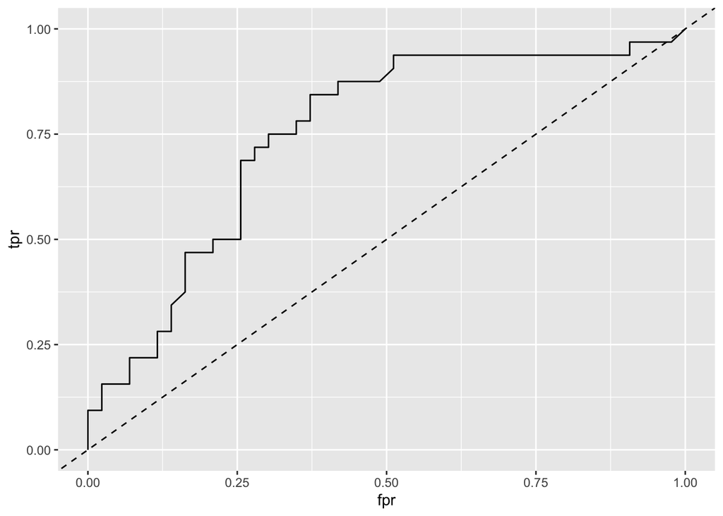

## model= rf filter= 0.1 outcome= lbo clin feat= g3+age

|  | Accuracy | Sensitivity | Specificity | AUC |
| --- | --- | --- | --- | --- |
| metric.mean.df | 0.707 | 0.625 | 0.767 | 0.715 |
| metric.quantiles | (0.707-0.707) | (0.625-0.625) | (0.767-0.767) | (0.715-0.715) |

|  | NPO-reference | Live_birth-reference |
| --- | --- | --- |
| NPO-prediction | 33 | 12 |
| Live_birth-prediction | 10 | 20 |

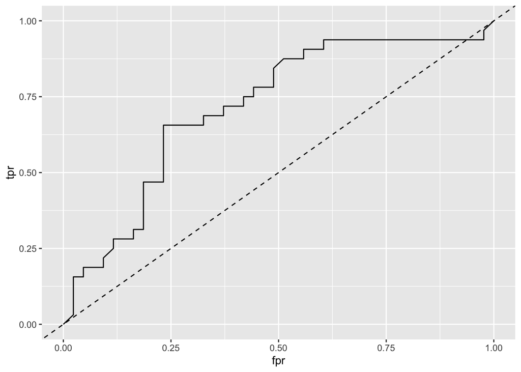

# Features

I have attached the features that were identified in each fold for each filtration percentage.

## 0.05 filter

```
## $`fold-1`
## [1] "APPL1"   "JMJD1C"  "RNVU1-7" "RN7SL4P" "RN7SL1"
##
## $`fold-2`
## [1] "PABPC4"   "PSMD4"    "JMJD1C"   "CLTB"     "SIVA1"    "MT-ATP6"  "HMGB1P10"
## [8] "RN7SL4P"  "RN7SL1"
##
## $`fold-3`
## [1] "RPS19"   "JMJD1C"  "SIVA1"   "RNVU1-7" "RN7SL4P" "RN7SL1"
##
## $`fold-4`
##  [1] "RPS19"    "PSMD4"    "JMJD1C"   "H1-5"     "SIVA1"    "MT-ATP6"
##  [7] "RNVU1-7"  "HMGB1P10" "RN7SL4P"  "RNU4ATAC" "RN7SL1"
##
## $`fold-5`
##  [1] "RPS19"    "APPL1"    "PSMD4"    "JMJD1C"   "H1-5"     "MT-ATP6"
##  [7] "RNVU1-7"  "HMGB1P10" "RN7SL4P"  "RNU4ATAC" "RN7SL1"
##
## $`fold-6`
## [1] "RPS19"    "PSMD4"    "JMJD1C"   "H1-5"     "MT-ATP6"  "RNVU1-7"  "RN7SL4P"
## [8] "RNU4ATAC" "RN7SL1"
##
## $`fold-7`
##  [1] "RPS19"    "RARS1"    "MED18"    "PSMD4"    "JMJD1C"   "H1-5"
##  [7] "MT-ATP6"  "RNVU1-7"  "HMGB1P10" "RN7SL4P"  "RNU4ATAC" "RN7SL1"
##
## $`fold-8`
##  [1] "RPS19"    "RARS1"    "MED18"    "APPL1"    "PSMD4"    "JMJD1C"
##  [7] "H1-5"     "MT-ATP6"  "RNVU1-7"  "HMGB1P10" "RN7SL4P"  "RNU4ATAC"
## [13] "RN7SL1"
##
## $`fold-9`
##  [1] "RPS19"    "RARS1"    "MACF1"    "MED18"    "APPL1"    "PSMD4"
##  [7] "JMJD1C"   "H1-5"     "SIVA1"    "MT-ATP6"  "RNVU1-7"  "HMGB1P10"
## [13] "RN7SL4P"  "RNU4ATAC" "RN7SL1"
##
## $`fold-10`
##  [1] "RPS19"           "RARS1"           "MACF1"           "MED18"
##  [5] "APPL1"           "PSMD4"           "PAFAH1B2"        "JMJD1C"
##  [9] "H1-5"            "SIVA1"           "MT-ATP6"         "RNVU1-7"
## [13] "HMGB1P10"        "RN7SL4P"         "RNU4ATAC"        "ENSG00000275110"
## [17] "RN7SL1"
```

## 0.1 filter

```
## $`fold-1`
## [1] "SMC1A"    "PABPC4"   "PSMD4"    "MT-ATP6"  "RNVU1-7"  "HMGB1P10" "RN7SL4P"
## [8] "RNU4ATAC" "RN7SL1"
##
## $`fold-2`
##  [1] "SMC1A"    "NDUFB2"   "PABPC4"   "RPS19"    "PELP1"    "PSMD4"
##  [7] "MT-ATP6"  "RNVU1-7"  "HMGB1P10" "RN7SL4P"  "RNU4ATAC" "RN7SL1"
##
## $`fold-3`
##  [1] "SMC1A"    "ATRX"     "PABPC4"   "RPS19"    "PELP1"    "PSMD4"
##  [7] "H1-5"     "MT-ATP6"  "RNVU1-7"  "HMGB1P10" "RN7SL4P"  "RNU4ATAC"
## [13] "RN7SL1"
##
## $`fold-4`
##  [1] "SMC1A"    "ATRX"     "NDUFB2"   "PABPC4"   "RPS19"    "G3BP2"
##  [7] "PELP1"    "PSMD4"    "H1-5"     "MT-ATP6"  "RNVU1-7"  "HMGB1P10"
## [13] "RN7SL4P"  "RNU4ATAC" "RN7SL1"
##
## $`fold-5`
##  [1] "SMC1A"    "ATRX"     "NDUFB2"   "PABPC4"   "RPS19"    "PELP1"
##  [7] "PSMD4"    "H1-5"     "MT-ATP6"  "RNVU1-7"  "HMGB1P10" "RN7SL4P"
## [13] "RNU4ATAC" "RN7SL1"
##
## $`fold-6`
##  [1] "SMC1A"    "ATRX"     "NDUFB2"   "PABPC4"   "RPS19"    "PELP1"
##  [7] "PSMD4"    "H1-5"     "MT-ATP6"  "RNVU1-7"  "HMGB1P10" "RN7SL4P"
## [13] "RNU4ATAC" "RN7SL1"
##
## $`fold-7`
##  [1] "SMC1A"    "ATRX"     "NDUFB2"   "PABPC4"   "RPS19"    "ILF3"
##  [7] "PELP1"    "PSMD4"    "H1-5"     "MT-ATP6"  "RNVU1-7"  "HMGB1P10"
## [13] "RN7SL4P"  "RNU4ATAC" "RN7SL1"
##
## $`fold-8`
##  [1] "SMC1A"    "ATRX"     "NDUFB2"   "PABPC4"   "RPS19"    "ILF3"
##  [7] "G3BP2"    "PELP1"    "PSMD4"    "SLC3A2"   "H1-5"     "MT-ATP6"
## [13] "RNVU1-7"  "HMGB1P10" "MALAT1"   "RN7SL4P"  "RNU4ATAC" "RN7SL1"
##
## $`fold-9`
##  [1] "SMC1A"    "ATRX"     "NDUFB2"   "PABPC4"   "RPS19"    "ILF3"
##  [7] "G3BP2"    "PELP1"    "PARP1"    "PSMD4"    "H1-5"     "MT-ATP6"
## [13] "RNVU1-7"  "HMGB1P10" "MALAT1"   "RN7SL4P"  "RNU4ATAC" "RN7SL1"
##
## $`fold-10`
##  [1] "SMC1A"           "ATRX"            "NDUFB2"          "PABPC4"
##  [5] "RPS19"           "ILF3"            "G3BP2"           "PELP1"
##  [9] "PARP1"           "PSMD4"           "SLC3A2"          "H1-5"
## [13] "MT-ATP6"         "RNVU1-7"         "HMGB1P10"        "MALAT1"
## [17] "RN7SL4P"         "RNU4ATAC"        "ENSG00000275110" "RN7SL1"
```

# Summary:

| Name | Accuracy | Sensitivity | Specificity | AUC |
| --- | --- | --- | --- | --- |
| model-ridge_filt-0.05_class-hCG_clin.feat- | 0.693 | 0.763 | 0.622 | 0.777 |
| model-ridge_filt-0.05_class-hCG_clin.feat-age | 0.693 | 0.763 | 0.622 | 0.792 |
| model-ridge_filt-0.05_class-hCG_clin.feat-g1+g2+g3 | 0.72 | 0.789 | 0.649 | 0.763 |
| model-ridge_filt-0.05_class-hCG_clin.feat-g1+g2+g3+age | 0.707 | 0.763 | 0.649 | 0.781 |
| model-ridge_filt-0.05_class-hCG_clin.feat-g3 | 0.667 | 0.711 | 0.622 | 0.775 |
| model-ridge_filt-0.05_class-hCG_clin.feat-g3+age | 0.707 | 0.763 | 0.649 | 0.781 |
| model-ridge_filt-0.1_class-hCG_clin.feat- | 0.733 | 0.737 | 0.73 | 0.835 |
| model-ridge_filt-0.1_class-hCG_clin.feat-age | 0.707 | 0.737 | 0.676 | 0.826 |
| model-ridge_filt-0.1_class-hCG_clin.feat-g1+g2+g3 | 0.76 | 0.763 | 0.757 | 0.84 |
| model-ridge_filt-0.1_class-hCG_clin.feat-g1+g2+g3+age | 0.747 | 0.763 | 0.73 | 0.846 |
| model-ridge_filt-0.1_class-hCG_clin.feat-g3 | 0.733 | 0.737 | 0.73 | 0.831 |
| model-ridge_filt-0.1_class-hCG_clin.feat-g3+age | 0.733 | 0.711 | 0.757 | 0.837 |
| model-ridge_filt-0.05_class-lbo_clin.feat- | 0.68 | 0.656 | 0.698 | 0.763 |
| model-ridge_filt-0.05_class-lbo_clin.feat-age | 0.667 | 0.656 | 0.674 | 0.762 |
| model-ridge_filt-0.05_class-lbo_clin.feat-g1+g2+g3 | 0.667 | 0.719 | 0.628 | 0.752 |
| model-ridge_filt-0.05_class-lbo_clin.feat-g1+g2+g3+age | 0.693 | 0.719 | 0.674 | 0.764 |
| model-ridge_filt-0.05_class-lbo_clin.feat-g3 | 0.733 | 0.781 | 0.698 | 0.789 |
| model-ridge_filt-0.05_class-lbo_clin.feat-g3+age | 0.76 | 0.781 | 0.744 | 0.782 |
| model-ridge_filt-0.1_class-lbo_clin.feat- | 0.76 | 0.719 | 0.791 | 0.778 |
| model-ridge_filt-0.1_class-lbo_clin.feat-age | 0.733 | 0.688 | 0.767 | 0.768 |
| model-ridge_filt-0.1_class-lbo_clin.feat-g1+g2+g3 | 0.693 | 0.625 | 0.744 | 0.762 |
| model-ridge_filt-0.1_class-lbo_clin.feat-g1+g2+g3+age | 0.693 | 0.656 | 0.721 | 0.785 |
| model-ridge_filt-0.1_class-lbo_clin.feat-g3 | 0.787 | 0.75 | 0.814 | 0.782 |
| model-ridge_filt-0.1_class-lbo_clin.feat-g3+age | 0.773 | 0.75 | 0.791 | 0.79 |
| model-rf_filt-0.05_class-hCG_clin.feat- | 0.667 | 0.737 | 0.595 | 0.707 |
| model-rf_filt-0.05_class-hCG_clin.feat-age | 0.653 | 0.684 | 0.622 | 0.703 |
| model-rf_filt-0.05_class-hCG_clin.feat-g1+g2+g3 | 0.693 | 0.763 | 0.622 | 0.733 |
| model-rf_filt-0.05_class-hCG_clin.feat-g1+g2+g3+age | 0.68 | 0.763 | 0.595 | 0.712 |
| model-rf_filt-0.05_class-hCG_clin.feat-g3 | 0.653 | 0.711 | 0.595 | 0.716 |
| model-rf_filt-0.05_class-hCG_clin.feat-g3+age | 0.68 | 0.763 | 0.595 | 0.693 |
| model-rf_filt-0.1_class-hCG_clin.feat- | 0.72 | 0.763 | 0.676 | 0.778 |
| model-rf_filt-0.1_class-hCG_clin.feat-age | 0.653 | 0.711 | 0.595 | 0.754 |
| model-rf_filt-0.1_class-hCG_clin.feat-g1+g2+g3 | 0.693 | 0.763 | 0.622 | 0.777 |
| model-rf_filt-0.1_class-hCG_clin.feat-g1+g2+g3+age | 0.733 | 0.789 | 0.676 | 0.78 |
| model-rf_filt-0.1_class-hCG_clin.feat-g3 | 0.667 | 0.737 | 0.595 | 0.766 |
| model-rf_filt-0.1_class-hCG_clin.feat-g3+age | 0.707 | 0.763 | 0.649 | 0.774 |
| model-rf_filt-0.05_class-lbo_clin.feat- | 0.627 | 0.531 | 0.698 | 0.689 |
| model-rf_filt-0.05_class-lbo_clin.feat-age | 0.6 | 0.5 | 0.674 | 0.698 |
| model-rf_filt-0.05_class-lbo_clin.feat-g1+g2+g3 | 0.64 | 0.594 | 0.674 | 0.737 |
| model-rf_filt-0.05_class-lbo_clin.feat-g1+g2+g3+age | 0.613 | 0.594 | 0.628 | 0.733 |
| model-rf_filt-0.05_class-lbo_clin.feat-g3 | 0.627 | 0.562 | 0.674 | 0.681 |
| model-rf_filt-0.05_class-lbo_clin.feat-g3+age | 0.627 | 0.594 | 0.651 | 0.706 |
| model-rf_filt-0.1_class-lbo_clin.feat- | 0.653 | 0.531 | 0.744 | 0.741 |
| model-rf_filt-0.1_class-lbo_clin.feat-age | 0.653 | 0.594 | 0.698 | 0.703 |
| model-rf_filt-0.1_class-lbo_clin.feat-g1+g2+g3 | 0.707 | 0.656 | 0.744 | 0.762 |
| model-rf_filt-0.1_class-lbo_clin.feat-g1+g2+g3+age | 0.68 | 0.625 | 0.721 | 0.721 |
| model-rf_filt-0.1_class-lbo_clin.feat-g3 | 0.707 | 0.688 | 0.721 | 0.747 |
| model-rf_filt-0.1_class-lbo_clin.feat-g3+age | 0.707 | 0.625 | 0.767 | 0.715 |